# Inferential statistics applied to a Stroop Effect measurement

This analysis aims to compute descriptive statistics and to perform a statistical test on a dataset based on a psychological phenomenon: the Stroop Effect. This report is structured into four sections: (1) *Introduction*, where the investigation problem is set; (2) *Descriptive Statistics*, where the data is parameterized statistically; (3) *Hypotheses Test*, in which a statistical test is applied to data and its results are reported; and (4) *Conclusion*, where an in-depth discussion on Stroop Effect is made.

- 1. Introduction
  - 1.1. The Stroop Effect
  - 1.2. Initial statements
  - 1.3. Understanding the data and their variables
  - 1.4. Hypotheses to be explored
- 2. Descriptive statistics
  - 2.1. Data statistics parameters
  - 2.2. Data distribution
- 3. Hypotheses test
- 4. Conclusions
- References

## 1. Introduction

### 1.1. The Stroop Effect

Accordingly to [1], the *Stroop Effect* is defined as follow:

> (...) the Stroop effect is a demonstration of interference in the reaction time of a task. When the name of a color (e.g., "blue", "green", or "red") is printed in a color that is not denoted by the name (e.g., the word "red" printed in blue ink instead of red ink), naming the color of the word takes longer and is more prone to errors than when the color of the ink matches the name of the color. The effect is named after John Ridley Stroop, who first published the effect in English in 1935.

These situations are defined as *congruent*, when the name of color is equivalent to the name, or *incongruent*, when the name denotes to another color, as shown in the following example sets.

**Congruent set of words:**

> **Green Red Blue Orange**

**Incongruent set of words:**

> **Green Red Blue Orange**

### 1.2. Initial statements

This section sets up import statements for all the packages that will be used throughout this python notebook.

```python
# Data analysis packages:
import pandas as pd
import numpy as np
#from datetime import datetime as dt

# Visualization packages:
import seaborn as sns
import matplotlib.pyplot as plt
%matplotlib inline
```

### 1.3. Understanding the data

The dataset used in this analysis is available at [3] and refers to the time of reading the ink color either for a list of congruent words and for a list of incongruent words. Each line of the dataset corresponds to a different person, in a total of 24 people, as confirmed below.

In order to define the hypotheses that will lead this analysis, it is first needed to know which information is available in the dataset (attributes). Thus, the first lines of the dataset are shown below:

```python
## Loading the dataset
dataset = pd.read_csv('stroopdata.csv')
## Printing the number of samples in the dataset:
print('The dataset has {0} samples.'.format(len(dataset)))
## Printing out some few lines:
dataset.head(3)
```

```
The dataset has 24 samples.
```

|  | Congruent | Incongruent |
| --- | --- | --- |
| 0 | 12.079 | 19.278 |
| 1 | 16.791 | 18.741 |
| 2 | 9.564 | 21.214 |

Once we have understood the phenomenon and the data available, we can then characterize the variables we are working with, as follow:

- **Independent variable**: the lists of **congruent** and **incongruent** words. In other words, the independent variables are those that did not depend on the sample and that are choosen a priori by the experimenter.
- **Dependent variable**: on the other hand, the dependent variable varies accordingly to each sample. In this problem, it refers to **the time to read and say out loud the color in which a set of words is printed**.

The population distribution for each one of the independent variables can then be described as follow:

- Time to read and say out loud the color of the congruent set of words: $(\mu_{cong}, \sigma_{cong})$;
- Time to read and say out loud the color of the incongruent set of words: $(\mu_{inc}, \sigma_{inc})$;

### 1.4. Hypotheses to be explored

Since the dataset we are considering has few samples, i.e. less than 30, we will assume that the population fits into a normal distribution. From this assumption we can then consider the sample mean as equivalent to the population mean. However, once we do not have the standard deviation of the population, it will be appropriate to consider a t-distribution.

Furthermore, through the t-test we could verify how different the two sample means (for congruent words and for incongruent words) are from each other, considering dependent samples (i.e. the same subject tests both for the congruent words and for the incongruent words).

Once we have defined the assumptions for the sample distributions as well as its mathematical notation, we can then define the hypotheses we will test throughout this analysis. From the previous few measurements we can notice that the time is higher for reading the incongruent set of words. Based on this we will formulate the following hypotheses:

$H_0: \mu_{cong} = \mu_{inc}$  
$H_a: \mu_{cong} < \mu_{inc}$

In order to test them we shall run a one-tailed t-test using an arbitrated $\alpha$ level of $0.05$, as it can be seen in Section 3.

## 2. Descriptive statistics

The term statistics here stands for the characteristics of the sample, in the way we could describe them in terms of its central tendency and variability.

The Python Pandas library offers a function to generate the descriptive statistics for a given dataset, summarizing its central tendency, dispersion and shape of the dataset's distribution. For numerical data, as it is the case, this function results in the following statistics: *count*, *mean*, *std* for the standard deviation, *min* and *max* values, the lower percentile (*25%*), the median or *50% percentile*, and the upper percentile (*75%*).

```python
## Obtaining the dataset descriptive statistics:
dataset.describe()
```

|  | Congruent | Incongruent |
| --- | --- | --- |
| count | 24.000000 | 24.000000 |
| mean | 14.051125 | 22.015917 |
| std | 3.559358 | 4.797057 |
| min | 8.630000 | 15.687000 |
| 25% | 11.895250 | 18.716750 |
| 50% | 14.356500 | 21.017500 |
| 75% | 16.200750 | 24.051500 |
| max | 22.328000 | 35.255000 |

From the values above we can see that in both sample distributions the *median* is close to the mean value, as it is supposed to be in a normal distribution. Thus it gaves us an idea on how is the central tendency of these distributions. The standard deviation values give us the information on how these distributions are spread out, indicating that the congruent values are closer to their mean.

These observed descriptive statistics are confirmed in the plot below, where both sample distributions can be visualized. Despite the outlier measurements in the distribution from *incongruent* word set, it can be noticed that both of them follow an approximately normal curve.

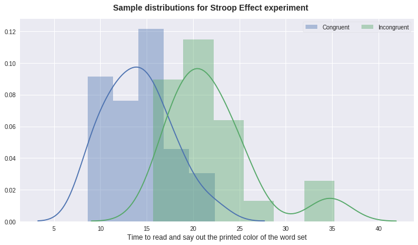

```python
fig1, ax = plt.subplots(figsize=[12,6])  #Defines the graph window size
fig1.subplots_adjust(top=0.92)
plt.suptitle('Sample distributions for Stroop Effect experiment', fontsize=14, fontweight='bold')

sns.distplot(dataset['Congruent'], label='Congruent', ax=ax)
sns.distplot(dataset['Incongruent'], label='Incongruent', ax=ax)
ax.legend(ncol=2, loc="upper right", frameon=True)

ax.set_xlabel('Time to read and say out the printed color of the word set', fontsize=12)
plt.show()
```

## 3. Hypotheses Test

In this section we will perform a t-test to evaluate the hypotheses set on Section 1.4, using as reference the class material of Udacity Nanodegree as well as the code available in [4].

As stated before, the following definitions must be considered:

- Hypotheses to test:
  - $H_0: \mu_{cong} = \mu_{inc}$
  - $H_a: \mu_{cong} < \mu_{inc}$
- One-tailed t-test with $\alpha$ level of $0.05$ and dependent sample.

### Calculating degrees of freedom

Since we are considering dependent sample, the degrees of freedom (*df*) are found by the following relation:  
${df} = n -1$, where $n$ is the number of samples.

```python
n = len(dataset)
df = n-1
print('Degrees of freedom: {}'.format(df))
```

```
Degrees of freedom: 23
```

### Calculating the difference

We know we are dealing with dependent sample (the subject who reads the congruent set of words is the same that reads the incongruent one), but we are interested in testing for an average difference among them. In [5] this approach of testing is also defined as *paired t-Test*.

In order to do so, we first need to calculate the difference between the variables:

```python
dataset['Difference'] = dataset['Congruent'] - dataset['Incongruent']
dataset.head(3)
```

|  | Congruent | Incongruent | Difference |
| --- | --- | --- | --- |
| 0 | 12.079 | 19.278 | -7.199 |
| 1 | 16.791 | 18.741 | -1.950 |
| 2 | 9.564 | 21.214 | -11.650 |

Now considering the difference, the hypotheses to be tested become:

- $H_0: \mu_{cong} - \mu_{inc} = 0$
- $H_a: \mu_{cong} - \mu_{inc} < 0$

And if we use $\mu_D$ to denote the difference, we can rewrite the hypotheses as:

- $H_0: \mu_D = 0$
- $H_a: \mu_D < 0$

To proceed the test, we need then to calculate the mean, $\bar{D}$, and its respective standard deviation $S_D$:

```python
## Difference mean
D = dataset['Difference'].mean()
print('Sample mean = {}'.format(D))
## Difference standard deviation
SD = dataset['Difference'].std()
print('Sample std = {}'.format(SD))
```

```
Sample mean = -7.96479166667
Sample std = 4.86482691036
```

With these values, we can now calculate the *standard error of the mean* as follow:  
${SEM} = S_D / \sqrt{n}$

```python
SEM = SD / np.sqrt(n)
print('SEM = {}'.format(SEM))
```

```
SEM = 0.993028634778
```

Finally, the t-test value is obtained from the relation:  
$t = \frac{\bar{D}}{{SEM}}$

```python
t = D / SEM
print('t-test = {}'.format(t))
```

```
t-test = -8.02070694411
```

### Calculating the p-value

Since we have defined an $\alpha$ level, it is know we are considering a *p-value* less than $\alpha$, i.e. $p < 0.05$. However, as this analysis runs over a computational platform, its exact value can be determined through the *stats* module of the *SciPy* library.

```python
from scipy import stats
```

```python
p = stats.t.cdf(t, df=df)
print('p-value = {0:.9f}'.format(p))
```

[output not shown]

In order to check the consistency of the results we have found, we will use a SciPy function to calculate the t-value and p-value:

```python
stats.ttest_rel(dataset['Congruent'],dataset['Incongruent'])
```

```
Ttest_relResult(statistic=-8.020706944109957, pvalue=4.1030005857111781e-08)
```

### Rejecting the null hypothesis

The $t_{critical}$ value is obtained from t-Table and when considering a one-tailed $\alpha = 0.05$, it corresponds to $t_{critical} = -1.714$.

Since the *t-test* value is much less than *t-critical*, **we reject the null** which means **we found significant statistics** to affirm that people read faster a set of congruent words when compared to incongruent ones, **which in turn is an evidence of the Stroop Effect**.

### Finding the confidence interval

The confidence interval (CI) is calculated from the following relation:  
${CI} = \bar{D} \pm {ME}$,

where ${ME}$ stands for margin of error and is calculated as follow:  
${ME} = t_{critical}*{SEM}$

```python
t_critical = 1.714
ME = t_critical*SEM
CI = (D-ME, D+ME)
print('Confidence interval: ({0:.2f}, {1:.2f})'.format(CI[0], CI[1]))
```

```
Confidence interval: (-9.67, -6.26)
```

**The CI above means that in average people read the congruent set of words almost 10 to 6 seconds faster than the incongruent one**.

## 4. Conclusions

Regarding the *Stroop Effect*, according to [2] it can be understood as an evidence in experimental psychology that a selective attention by properties is either nonexistent or incomplete. This is due to early experiments that seemed to indicate that if an object is attended, some of its properties would be processed in an automatic way, even when the observer were trying to ignore them. The findings from Stroop Effect bring evidences that selective attention to color may not be possible after all. Still according to [2], the Stroop interference also occurs when subjects are asked to name an object that is drawn in outline around the name of a different object, for example.

In this analysis we presented the Stroop Effect and applyed a t-test to collect statistic evidence to support this perceptive phenomenon. In doing so, we have gone through the steps necessary to test a hypothesis as well as gain confidence that the method can be valid even for a small number of samples, provided certain conditions.

## References

[1] Wikipedia contributors. *Stroop effect*. Wikipedia, The Free Encyclopedia. Available at: https://en.wikipedia.org/wiki/Stroop_effect. Accessed in May 1st, 2018.

[2] Palmer, S.E. (1999). *Vision Science: Photons to Phenomenology*. MIT Press.

[3] Udacity. *Stroop Effect Dataset*. Available at: https://www.google.com/url?q=https://drive.google.com/file/d/0B9Yf01UaIbUgQXpYb2NhZ29yX1U/view?usp%3Dsharing&sa=D&ust=1525216530059000. Accessed in May 1st, 2018.

[4] Aankul A. *T-test using Python and Numpy*. Towards Data Science. Available at: https://towardsdatascience.com/inferential-statistics-series-t-test-using-numpy-2718f8f9bf2f. Accessed in May 3rd, 2018.

[5] Rumsey, D. (2011) *Statistics for dummies*. 2nd Edition. Wiley.